# IE 440 - Final Question 1

Yusuf Ulucoban

207402021

## Data Import and Plotting

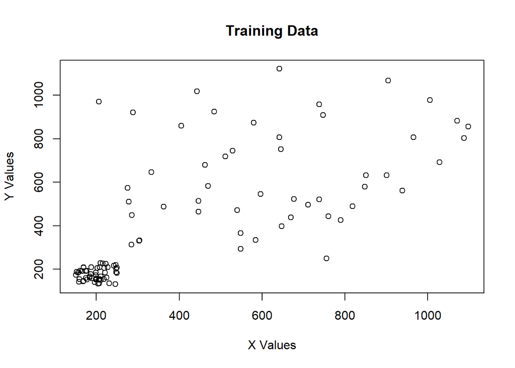

```r
training <- data.table(read.table("C:/Users/yuluc/OneDrive/Desktop/IE440Final21Training.txt"))
test <- data.table(read.table("C:/Users/yuluc/OneDrive/Desktop/IE440Final21Test.txt"))

plot(training, xlab = "X Values", ylab = "Y Values", main = "Training Data")
```

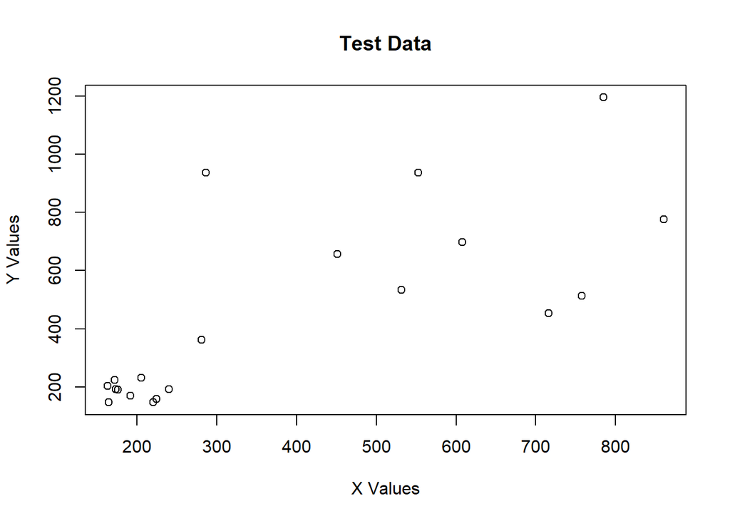

```r
plot(test, xlab = "X Values", ylab = "Y Values", main = "Test Data")
```

## Explanations for Question1

From now on, I will use following naming system for the both parts of the first question.  
constant_i_j means the constant unknown for the partial derivative of i’th part according to j. For example constant_2_a is constant value of a in the second part of the question which is polynomial regression model.  
i_variable_j_k means the unknown for the partial derivative of j’th part of the question according to k, where our parameter will be written in the side of i.  
As a result  
the system will be  
constant_1_a + a_variable_1_a * a + b_variable_1_a * b = 0  
constant_1_b + a_variable_1_b * a + b_variable_1_b * b = 0  
equations should hold for the optimal value in the part a

and also  
constant_2_a + a_variable_2_a * a + b_variable_2_a * b + c_variable_2_a * c + d_variable_2_a * d = 0  
constant_2_b + a_variable_2_b * a + b_variable_2_b * b + c_variable_2_b * c + d_variable_2_b * d = 0  
constant_2_c + a_variable_2_c * a + b_variable_2_c * b + c_variable_2_c * c + d_variable_2_c * d = 0  
constant_2_d + a_variable_2_d * a + b_variable_2_d * b + c_variable_2_d * c + d_variable_2_d * d = 0  
equations should hold for the optimal value in the part b.

## Question 1.a, Linear Regression and Calculations

As you can observe, the objective value which is summation of the errors between actual values and predictions should be minimized. The general formula could be written as “(y - b - (a * x))^2” when linear regression model is used.  
To reach optimal a and b values, partial derivatives of the objection function are needed.

```r
constant_1_a = sum(2 * training$V2 * (-training$V1))
a_variable_1_a = sum(2 * training$V1 * training$V1)
b_variable_1_a = sum(2 * training$V1)

constant_1_b = sum(-training$V2 * 2)
a_variable_1_b = sum(training$V1 * 2)
b_variable_1_b = nrow(training) * 2

unknowns1 = c(constant_1_a,
a_variable_1_a,
b_variable_1_a,
constant_1_b,
a_variable_1_b,
b_variable_1_b)

unknownsmatrix1 = matrix(unknowns1, nrow = 2, ncol = 3, byrow= TRUE)
unknownsmatrix1
```

```
##              [,1]        [,2]     [,3]
## [1,] -44721020.24 48857055.81 82266.28
## [2,]    -81690.13    82266.28   200.00
```

Which leads us to the equations from the derivatives.

**-44721020.238376 + 48857055.8056649 * a + 82266.2786875371 * b = 0**  
**-81690.1261714459 + 82266.2786875371 * a + 200 * b = 0**

From these equations it is reached that  
**a = 0.7403812513747**  
**b = 103.90857905412**

Now let us plot the linear regression line and the all the points in the training data.

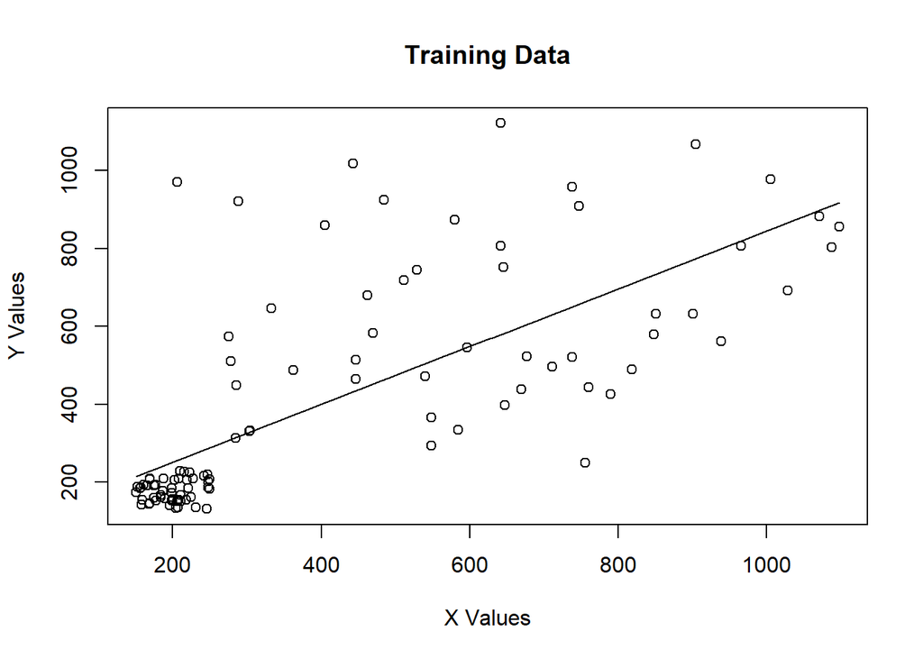

```r
a = 0.7403812513747
b = 103.90857905412

plot(training, xlab = "X Values", ylab = "Y Values", main = "Training Data")
curve(a * x + b, add = TRUE)
```

Next step is creating the results table to store all of the errors in one table, and fill the first row with the errors according to our a and b values.

```r
df <- data.frame(matrix(ncol = 4, nrow = 0))
x <- c("Method", "Training SSE", "Test MSE", "s^2 for Test MSE")
colnames(df) <- x
df[1,1] = "1a"
df[2,1] = "1b"
df[3,1] = "2a"
df[4,1] = "2b"

training1a = cbind(training, a * training[,1] + b)
SSE1a = sum((training1a[,3] - training1a[,2])^2)

test1a <- test
test1a = cbind(test1a, a * test1a[,1] + b)

TestMSE1a = sum((test1a[,3] - test1a[,2])^2) / 20

Var1a = (sum((TestMSE1a - (test1a[,3] - test1a[,2])^2)^2)) / 19


df[1,2] = SSE1a
df[1,3] = TestMSE1a
df[1,4] = Var1a

df
```

```
##   Method Training SSE Test MSE s^2 for Test MSE
## 1     1a      3834771  50217.3      10655325557
## 2     1b           NA       NA               NA
## 3     2a           NA       NA               NA
## 4     2b           NA       NA               NA
```

## Question 1.b, Polynomial Regression and Calculations

As you can observe, the objective value which is summation of the errors between actual values and predictions should be minimized. The general formula could be written as “(y - d - (c * x) - (b * x^2) - (a * x<sup>3))</sup>2” when polynomial regression model is used.  
To reach optimal a, b, c and d values, partial derivatives of the objection function are needed.

```r
constant_2_a = sum(2 * training$V2 * -(training$V1)^3)
a_variable_2_a = sum(2 * (training$V1)^6)
b_variable_2_a = sum(2 * (training$V1)^5)
c_variable_2_a = sum(2 * (training$V1)^4)
d_variable_2_a = sum(2 * (training$V1)^3)

constant_2_b = sum(2 * training$V2 * -(training$V1)^2)
a_variable_2_b = sum(2 * (training$V1)^5)
b_variable_2_b = sum(2 * (training$V1)^4)
c_variable_2_b = sum(2 * (training$V1)^3)
d_variable_2_b = sum(2 * (training$V1)^2)

constant_2_c = sum(2 * training$V2 * -(training$V1))
a_variable_2_c = sum(2 * (training$V1)^4)
b_variable_2_c = sum(2 * (training$V1)^3)
c_variable_2_c = sum(2 * (training$V1)^2)
d_variable_2_c = sum(2 * (training$V1))

constant_2_d = sum(-2 * training$V2)
a_variable_2_d = sum(2 * (training$V1)^3)
b_variable_2_d = sum(2 * (training$V1)^2)
c_variable_2_d = sum(2 * (training$V1))
d_variable_2_d = nrow(training) * 2

unknowns2 = c(  constant_2_a,
               a_variable_2_a,
               b_variable_2_a,
               c_variable_2_a,
               d_variable_2_a,

               constant_2_b,
               a_variable_2_b,
               b_variable_2_b,
               c_variable_2_b,
               d_variable_2_b,

               constant_2_c,
               a_variable_2_c,
               b_variable_2_c,
               c_variable_2_c,
               d_variable_2_c,

               constant_2_d,
               a_variable_2_d,
               b_variable_2_d,
               c_variable_2_d,
               d_variable_2_d)

unknownsmatrix2 = matrix(unknowns2, nrow = 4, ncol = 5, byrow= TRUE)
unknownsmatrix2
```

```
##               [,1]         [,2]         [,3]         [,4]         [,5]
## [1,] -2.527646e+13 2.556551e+19 2.740066e+16 3.060682e+13 3.646834e+10
## [2,] -3.132556e+10 2.740066e+16 3.060682e+13 3.646834e+10 4.885706e+07
## [3,] -4.472102e+07 3.060682e+13 3.646834e+10 4.885706e+07 8.226628e+04
## [4,] -8.169013e+04 3.646834e+10 4.885706e+07 8.226628e+04 2.000000e+02
```

Which leads us to the equations from the derivatives.

**-2.527646e+13 + 2.556551e+19 * a + 2.740066e+16 * b + 3.060682e+13 * c + 3.646834e+10 * d = 0**  
**-3.132556e+10 + 2.740066e+16 * a + 3.060682e+13 * b + 3.646834e+10 * c + 4.885706e+07 * d = 0**  
**-4.472102e+07 + 3.060682e+13 * a + 3.646834e+10 * b + 4.885706e+07 * c + 8.226628e+04 * d = 0**  
**-8.169013e+04 + 3.646834e+10 * a + 4.885706e+07 * b + 8.226628e+04 * c + 2.000000e+02 * d = 0**

From these equations it is reached that  
**a = 0.000003949602497661346**  
**b = -0.007999048439504993**  
**c = 5.356141005604576**  
**d = -560.8256143864088**

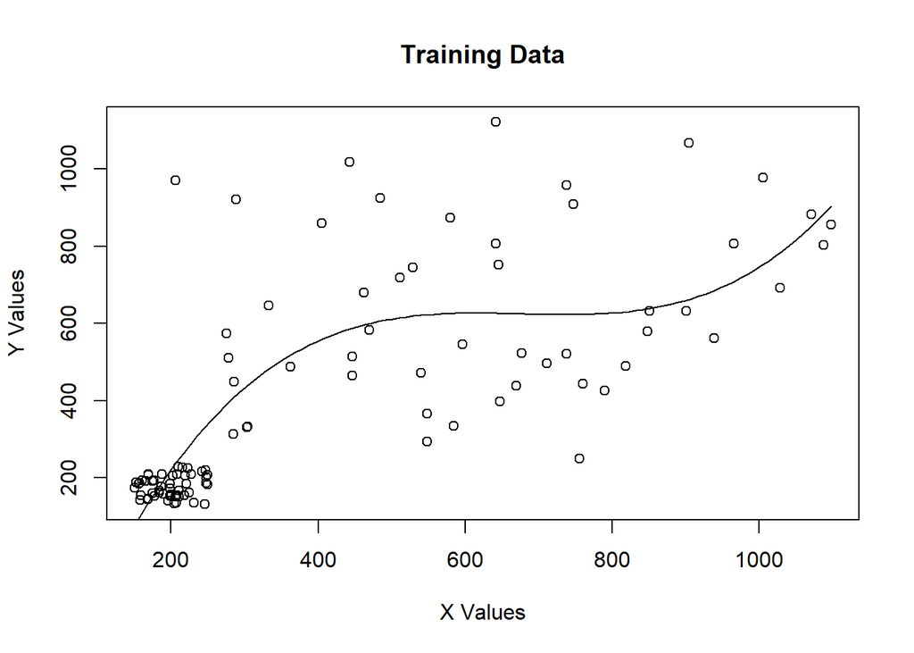

```r
a = 0.000003949602497661346
b = -0.007999048439504993
c = 5.356141005604576
d = -560.8256143864088

plot.default(training, xlab = "X Values", ylab = "Y Values", main = "Training Data")
curve(a * x^3 + b * x^2 + c * x + d, add = TRUE)
```

It is time to fulfill our results table, df.

```r
training1b = cbind(training, a * training[,1]^3 + b * training[,1]^2 + c * training[,1] + d)
SSE1b = sum((training1b[,3] - training1b[,2])^2)

test1b <- test
test1b = cbind(test1b, a * training[,1]^3 + b * training[,1]^2 + c * training[,1] + d)

TestMSE1b = sum((test1b[,3] - test1b[,2])^2) / 20

Var1b = (sum((TestMSE1b - (test1b[,3] - test1b[,2])^2)^2)) / 19

df[2,2] = SSE1b
df[2,3] = TestMSE1b
df[2,4] = Var1b

df
```

```
##   Method Training SSE Test MSE s^2 for Test MSE
## 1     1a      3834771  50217.3     1.065533e+10
## 2     1b      3146364 591611.3     1.340386e+12
## 3     2a           NA       NA               NA
## 4     2b           NA       NA               NA
```

## Question 2.a, BackPropagation Algorithm and Hidden Units

Firstly, lets try to create our random wij and Wjk values with runif function.  
As the question suggests, number of hidden layers will be 3 at the beginning.

```r
training <- data.table(read.table("C:/Users/yuluc/OneDrive/Desktop/IE440Final21Training.txt"))
test <- data.table(read.table("C:/Users/yuluc/OneDrive/Desktop/IE440Final21Test.txt"))

xvalues <- matrix(training$V1)
yvalues <- matrix(training$V2)

neural_network <- list(
  input = cbind(rep(1,100), xvalues),
  weights1 = matrix(runif(6), ncol = 3),
  weights2 = matrix(runif(3), ncol = 1),
  y = yvalues,
  output = matrix(
    rep(0, times = 100),
    ncol = 1
  )
)
```

Now, the sigmoid function and the derivative of the sigmoid function should be defined.

```r
sigmoid <- function(x) {
  1 / (1 + exp(-x))
}

sigmoid_derivative <- function(x) {
  #  x * (1.0 - x)
  #  sigmoid(x) * (1 - sigmoid(x))
  exp(-x) * (1+exp(-x))^(-2)
}
```

Now, lets try to create backpropagation function in order to find weights.  
The most important point is since our sigmoid function does not properly work for big numbers, I decided to work with numbers that are around 0.5. So, I will firstly divide inputs and results to 10000 and later, I will multiply.

```r
alpha <- c(0.5)
eta <- 0.9
error <- 0.001
k = 1
neural_network$input <- neural_network$input / 10000
neural_network$y <- neural_network$y / 10000
while(alpha[k] > error){
  neural_network$hidden <- sigmoid(neural_network$input %*% neural_network$weights1)
  neural_network$output <- sigmoid(neural_network$hidden %*% neural_network$weights2)

  previousw1 = neural_network$weights1
  previousw2 = neural_network$weights2

  d_weights2 <- (t(neural_network$hidden) %*% (2*(neural_network$y - neural_network$output) * sigmoid_derivative(neural_network$output)))
  d_weights1 <- ( 2 * (neural_network$y - neural_network$output) * sigmoid_derivative(neural_network$output)) %*% t(neural_network$weights2)
  d_weights1 <- d_weights1 * sigmoid_derivative(neural_network$hidden)
  d_weights1 <- t(neural_network$input) %*% d_weights1

  neural_network$weights1 <- neural_network$weights1 + d_weights1
  neural_network$weights2 <- neural_network$weights2 + d_weights2
  alpha[k+1] = eta * alpha[k]
  k = k+1
}

neural_network$y <- neural_network$y * 10000
neural_network$output <- neural_network$output * 10000
```

Lets check weights.

```r
data.frame(
neural_network$weights1
)
```

```
##           X1         X2         X3
## 1  0.4123906  0.1854481  0.6177768
## 2 -3.3943085 -3.3455389 -2.8140434
```

```r
data.frame(
neural_network$weights2
)
```

```
##   neural_network.weights2
## 1               -2.395091
## 2               -2.363110
## 3               -2.054656
```

It seems that our algorithm managed to find some weights for 3 different hidden units where weights1 represents from input to 3 hidden units and weights2 represents from 3 hidden units to one output unit. Now lets check predictions.

```r
data.frame(
  "Predicted" = neural_network$output,
  "Actual" = neural_network$y
)
```

```
##     Predicted    Actual
## 1    357.1986  205.9120
## 2    365.4837  131.7401
## 3    360.1054  154.8883
## 4    358.2321  209.4287
## 5    365.7600  203.2680
## 6    365.8898  186.0544
## 7    348.6674  184.8220
## 8    352.6596  152.4926
## 9    349.4988  193.6386
## 10   358.7178  167.6015
## 11   358.2972  154.4636
## 12   347.6655  174.8635
## 13   361.4753  161.5420
## 14   351.0850  207.8832
```

[output cut: 86 more lines]

Although, predictions are does not seem quite successful, it is believed that they are most successful predictions aaccording to 3 hidden units and random starting weights.  
Now, MSE should be calculated to store.

```r
SSE2a <- sum((neural_network$output - neural_network$y)^2)
```

Next step is to define hidden units function.  
Firstly, the weights that are found for training data should be applied for test data and the error must be calculated.  
Also, the prediction for the test data should be controlled only for once, this phase will not be needed in the next steps.

```r
x <- matrix(test$V1)
y <- matrix(test$V2)

neural_network <- list(
  input = cbind(rep(1,20), x),
  weights1 = previousw1,
  weights2 = previousw2,
  y = y,
  output = matrix(
    rep(0, times = 20),
    ncol = 1)
)

neural_network$input = neural_network$input / 10000
neural_network$hidden <- sigmoid(neural_network$input %*% neural_network$weights1)
neural_network$output <- sigmoid(neural_network$hidden %*% neural_network$weights2)
neural_network$output = neural_network$output * 10000

data.frame(
  "Predicted" = neural_network$output,
  "Actual" = neural_network$y
)
```

```
##    Predicted    Actual
## 1   357.7589  230.5372
## 2   351.9150  192.3530
## 3   352.4022  189.8427
## 4   360.5667  148.2310
## 5   351.5692  224.3023
## 6   349.9662  203.7733
## 7   355.2616  170.3158
## 8   350.2054  147.0985
## 9   361.4149  158.6911
## 10  364.4032  192.2136
## 11  482.7780 1194.7941
## 12  440.9792  697.2306
## 13  423.9436  533.2475
## 14  466.1526  453.9665
## 15  373.2180  936.5668
## 16  428.5777  936.2107
## 17  406.6315  656.7765
## 18  372.1504  361.1037
## 19  476.1756  513.5135
## 20  501.6102  776.3129
```

```r
E = c(mean((neural_network$y - neural_network$output)^2))
k = 1
J = 3
controlmatrix = c(k,J,E)
errors = c(k,J,SSE2a,0,0)
```

Now, it is time to create a function that will find optimal number of hidden units.

```r
while(k<50){
  J <- J+1

  xvalues <- matrix(training$V1)
  yvalues <- matrix(training$V2)

  neural_network <- list(
    input = cbind(rep(1,100), xvalues),
    weights1 = matrix(runif(2*J), ncol = J),
    weights2 = matrix(runif(J), ncol = 1),
    y = yvalues,
    output = matrix(
      rep(0, times = 100),
      ncol = 1
    )
  )

  alpha <- c(0.5)
  eta <- 0.9
  error <- 0.001
  i = 1
  neural_network$input <- neural_network$input / 10000
  neural_network$y <- neural_network$y / 10000
  while(alpha[i] > error){
    neural_network$hidden <- sigmoid(neural_network$input %*% neural_network$weights1)
    neural_network$output <- sigmoid(neural_network$hidden %*% neural_network$weights2)

    previousw1 = neural_network$weights1
    previousw2 = neural_network$weights2

    d_weights2 <- (t(neural_network$hidden) %*% (2*(neural_network$y - neural_network$output) * sigmoid_derivative(neural_network$output)))
    d_weights1 <- ( 2 * (neural_network$y - neural_network$output) * sigmoid_derivative(neural_network$output)) %*% t(neural_network$weights2)
    d_weights1 <- d_weights1 * sigmoid_derivative(neural_network$hidden)
    d_weights1 <- t(neural_network$input) %*% d_weights1

    neural_network$weights1 <- neural_network$weights1 + d_weights1
    neural_network$weights2 <- neural_network$weights2 + d_weights2
    alpha[i+1] = eta * alpha[i]
    i = i+1
  }
  neural_network$y <- neural_network$y * 10000
  neural_network$output <- neural_network$output * 10000

  SSE2a <- sum((neural_network$output - neural_network$y)^2)

  xtest <- matrix(test$V1)
  ytest <- matrix(test$V2)

  neural_network_test <- list(
    input = cbind(rep(1,20), xtest),
    weights1 = previousw1,
    weights2 = previousw2,
    y = ytest,
    output = matrix(
      rep(0, times = 20),
      ncol = 1)
  )
  neural_network_test$input = neural_network_test$input / 10000
  neural_network_test$hidden <- sigmoid(neural_network_test$input %*% neural_network_test$weights1)
  neural_network_test$output <- sigmoid(neural_network_test$hidden %*% neural_network_test$weights2)
  neural_network_test$output = neural_network_test$output * 10000

  TestMSE1a = sum((neural_network_test$y -  neural_network_test$output)^2) / 20
  Var1a = (sum((TestMSE1a - (neural_network_test$y - neural_network_test$output)^2)^2)) / 19
  errors = rbind(errors, c(k+1,J,SSE2a,TestMSE1a,Var1a))

  E = c(mean((neural_network_test$y - neural_network_test$output)^2))
  k = k+1
  temp = NULL
  temp = c(k,J,E)
  controlmatrix = rbind(controlmatrix,temp)
}

x <- c("k", "J", "Error")
colnames(controlmatrix) <- x
controlmatrix = data.table(controlmatrix)
resultoffirsttemplate = controlmatrix[which.min(controlmatrix$Error),]
controlmatrix[which.min(controlmatrix$Error),]
```

[output not shown]

```r
forerrors = controlmatrix[which.min(controlmatrix$Error),]
flag = forerrors[1,1]
flag=as.numeric(flag)
df[3,2] = errors[flag,3]
df[3,3] = errors[flag,4]
df[3,4] = errors[flag,5]
df
```

```
##   Method Training SSE  Test MSE s^2 for Test MSE
## 1     1a      3834771  50217.30     1.065533e+10
## 2     1b      3146364 591611.29     1.340386e+12
## 3     2a      5391842  67655.42     1.911086e+10
## 4     2b           NA        NA               NA
```

## Question 2.b, BackPropagation Algorithm and Hidden Units

Now, all steps will be applied for 4 input units template. This situation will affect weight matrices and the rest is the same.

```r
training <- data.table(read.table("C:/Users/yuluc/OneDrive/Desktop/IE440Final21Training.txt"))
test <- data.table(read.table("C:/Users/yuluc/OneDrive/Desktop/IE440Final21Test.txt"))

xvalues <- matrix(training$V1)
yvalues <- matrix(training$V2)

neural_network <- list(
  input = cbind(rep(1,100), xvalues, (xvalues^2), (xvalues^3)),
  weights1 = matrix(runif(12), ncol = 3),
  weights2 = matrix(runif(3), ncol = 1),
  y = yvalues,
  output = matrix(
    rep(0, times = 100),
    ncol = 1
  )
)

alpha <- c(0.5)
eta <- 0.9
error <- 0.001
k = 1
neural_network$input <- neural_network$input / (10000)^2
neural_network$y <- neural_network$y / (10000)^2
while(alpha[k] > error){
  neural_network$hidden <- sigmoid(neural_network$input %*% neural_network$weights1)
  neural_network$output <- sigmoid(neural_network$hidden %*% neural_network$weights2)

  previousw1 = neural_network$weights1
  previousw2 = neural_network$weights2

  d_weights2 <- (t(neural_network$hidden) %*% (2*(neural_network$y - neural_network$output) * sigmoid_derivative(neural_network$output)))
  d_weights1 <- ( 2 * (neural_network$y - neural_network$output) * sigmoid_derivative(neural_network$output)) %*% t(neural_network$weights2)
  d_weights1 <- d_weights1 * sigmoid_derivative(neural_network$hidden)
  d_weights1 <- t(neural_network$input) %*% d_weights1

  neural_network$weights1 <- neural_network$weights1 + d_weights1
  neural_network$weights2 <- neural_network$weights2 + d_weights2
  alpha[k+1] = eta * alpha[k]
  k = k+1
}

neural_network$y <- neural_network$y * (10000)^2
neural_network$output <- neural_network$output * (10000)^2



data.frame(
  neural_network$weights1
)
```

```
##            X1          X2          X3
## 1   0.3550427   0.1217280   0.3778918
## 2   0.6685186   0.7607467   0.9713615
## 3   0.2364539   1.1031657   0.6206595
## 4 163.2066298 151.0610939 202.1254435
```

```r
data.frame(
  neural_network$weights2
)
```

```
##   neural_network.weights2
## 1               -16.97489
## 2               -15.28225
## 3               -20.30829
```

```r
SSE2a <- sum((neural_network$output - neural_network$y)^2)
```

Now, it is obvious that our algorithm is able to find weights and make predictions.  
So, the next step is to find optimal number of hidden units. Same algortihm that it is used in the question 2a will be used, so there is no need for more explanations.

```r
x <- matrix(test$V1)
y <- matrix(test$V2)

neural_network <- list(
  input = cbind(rep(1,20), x, x^2, x^3),
  weights1 = previousw1,
  weights2 = previousw2,
  y = y,
  output = matrix(
    rep(0, times = 20),
    ncol = 1)
)

neural_network$input = neural_network$input / 10000
neural_network$hidden <- sigmoid(neural_network$input %*% neural_network$weights1)
neural_network$output <- sigmoid(neural_network$hidden %*% neural_network$weights2)
neural_network$output = neural_network$output * 10000

E = c(mean((neural_network$y - neural_network$output)^2))
k = 1
J = 3
controlmatrix = c(k,J,E)
errorsb = c(k,J,SSE2a,0,0)

while(k<50){
  J <- J+1

  xvalues <- matrix(training$V1)
  yvalues <- matrix(training$V2)

  neural_network <- list(
    input = cbind(rep(1,100), xvalues, (xvalues^2), (xvalues^3)),
    weights1 = matrix(runif(4*J), ncol = J),
    weights2 = matrix(runif(J), ncol = 1),
    y = yvalues,
    output = matrix(
      rep(0, times = 100),
      ncol = 1
    )
  )

  alpha <- c(0.5)
  eta <- 0.9
  error <- 0.001
  i = 1
  neural_network$input <- neural_network$input / 10000
  neural_network$y <- neural_network$y / 10000



  while(alpha[i] > error){
    neural_network$hidden <- sigmoid(neural_network$input %*% neural_network$weights1)
    neural_network$output <- sigmoid(neural_network$hidden %*% neural_network$weights2)

    previousw1 = neural_network$weights1
    previousw2 = neural_network$weights2

    d_weights2 <- (t(neural_network$hidden) %*% (2*(neural_network$y - neural_network$output) * sigmoid_derivative(neural_network$output)))
    d_weights1 <- ( 2 * (neural_network$y - neural_network$output) * sigmoid_derivative(neural_network$output)) %*% t(neural_network$weights2)
    d_weights1 <- d_weights1 * sigmoid_derivative(neural_network$hidden)
    d_weights1 <- t(neural_network$input) %*% d_weights1

    neural_network$weights1 <- neural_network$weights1 + d_weights1
    neural_network$weights2 <- neural_network$weights2 + d_weights2
    alpha[i+1] = eta * alpha[i]
    i = i+1
  }





  neural_network$y <- neural_network$y * 10000
  neural_network$output <- neural_network$output * 10000

  SSE2b <- sum((neural_network$output - neural_network$y)^2)

  xtest <- matrix(test$V1)
  ytest <- matrix(test$V2)

  neural_network_test <- list(
    input = cbind(rep(1,20), xtest, (xtest^2), (xtest^3)),
    weights1 = previousw1,
    weights2 = previousw2,
    y = ytest,
    output = matrix(
      rep(0, times = 20),
      ncol = 1)
  )
  neural_network_test$input = neural_network_test$input / 10000
  neural_network_test$hidden <- sigmoid(neural_network_test$input %*% neural_network_test$weights1)
  neural_network_test$output <- sigmoid(neural_network_test$hidden %*% neural_network_test$weights2)
  neural_network_test$output = neural_network_test$output * 10000

  TestMSE1b = sum((neural_network_test$y -  neural_network_test$output)^2) / 20
  Var1b = (sum((TestMSE1a - (neural_network_test$y - neural_network_test$output)^2)^2)) / 19
  errorsb = rbind(errorsb, c(k+1,J,SSE2b,TestMSE1b,Var1b))

  E = c(mean((neural_network_test$y - neural_network_test$output)^2))
  k = k+1
  temp = NULL
  temp = c(k,J,E)
  controlmatrix = rbind(controlmatrix,temp)
}

x <- c("k", "J", "Error")
colnames(controlmatrix) <- x
controlmatrix = data.table(controlmatrix)
resultofsecondtemplate = controlmatrix[which.min(controlmatrix$Error),]
controlmatrix[which.min(controlmatrix$Error),]
```

```
##    k J    Error
## 1: 2 4 293568.8
```

```r
forerrors = controlmatrix[which.min(controlmatrix$Error),]
flag = forerrors[1,1]
flag=as.numeric(flag)
df[4,2] = errorsb[flag,3]
df[4,3] = errorsb[flag,4]
df[4,4] = errorsb[flag,5]
```

## Results

As you followed, all the answers are found where J is number of hidden units.  
Number of optimal hidden units for the part a is below.

```r
resultoffirsttemplate
```

[output not shown]

Also, number of optimal hidden units for the part b is below.

```r
resultofsecondtemplate
```

```
##    k J    Error
## 1: 2 4 293568.8
```

Lastly, results table “df” is able to be observed.

```r
df
```

```
##   Method Training SSE  Test MSE s^2 for Test MSE
## 1     1a      3834771  50217.30     1.065533e+10
## 2     1b      3146364 591611.29     1.340386e+12
## 3     2a      5391842  67655.42     1.911086e+10
## 4     2b     24326293 293568.76     1.466753e+11
```